# Assignment B: Computer Vision (CS7GV1)

## Van Allen Bruns Jr - 19329560

# 2) Image denoising (10 marks): Read paper Beyond a Gaussian Denoiser: Residual Learning of Deep CNN for Image Denoising (https://arxiv.org/abs/1608.03981). From the class drive download archive DnCNN.zip which contains the dataset, data preparation, training and testing scripts. You are provided with DnCNN-s model pretrained to denoise images with σ=25.

#### main_test.py seen below, modified to have a test function with parameters.

```python
# -*- coding: utf-8 -*-

# =============================================================================
#  @article{zhang2017beyond,
#    title={Beyond a {Gaussian} denoiser: Residual learning of deep {CNN} for image denoising},
#    author={Zhang, Kai and Zuo, Wangmeng and Chen, Yunjin and Meng, Deyu and Zhang, Lei},
#    journal={IEEE Transactions on Image Processing},
#    year={2017},
#    volume={26},
#    number={7},
#    pages={3142-3155},
#  }
# modified version of the code from https://github.com/cszn/DnCNN
# =============================================================================

# run this to test the model

import argparse
import os, time, datetime
import numpy as np
import torch.nn as nn
import torch.nn.init as init
import torch
from skimage.measure import compare_psnr, compare_ssim
from skimage.io import imread, imsave


def log(*args, **kwargs):
     print(datetime.datetime.now().strftime("%Y-%m-%d %H:%M:%S:"), *args, **kwargs)


def save_result(result, path):
    path = path if path.find('.') != -1 else path+'.png'
    ext = os.path.splitext(path)[-1]
    if ext in ('.txt', '.dlm'):
        np.savetxt(path, result, fmt='%2.4f')
    else:
        imsave(path, np.uint8(np.clip(result*255.0, 0, 255)))


def show(x, title=None, cbar=False, figsize=None):
    import matplotlib.pyplot as plt
    plt.figure(figsize=figsize)
    plt.imshow(x, interpolation='nearest', cmap='gray')
    if title:
        plt.title(title)
    if cbar:
        plt.colorbar()
    plt.show()


class DnCNN(nn.Module):

    def __init__(self, depth=17, n_channels=64, image_channels=1, use_bnorm=True, kernel_size=3):
        super(DnCNN, self).__init__()
        kernel_size = 3
        padding = 1
        layers = []
        layers.append(nn.Conv2d(in_channels=image_channels, out_channels=n_channels, kernel_size=kernel_size,
                                padding=padding, bias=True))
        layers.append(nn.ReLU(inplace=True))
        for _ in range(depth-2):
            layers.append(nn.Conv2d(in_channels=n_channels, out_channels=n_channels, kernel_size=kernel_size,
                                    padding=padding, bias=False))
            layers.append(nn.BatchNorm2d(n_channels))
            layers.append(nn.ReLU(inplace=True))
        layers.append(nn.Conv2d(in_channels=n_channels, out_channels=image_channels, kernel_size=kernel_size,
                                padding=padding, bias=False))
        self.dncnn = nn.Sequential(*layers)
        self._initialize_weights()

    def forward(self, x):
        y = x
        out = self.dncnn(x)
        return y-out

    def _initialize_weights(self):
        for m in self.modules():
            if isinstance(m, nn.Conv2d):
                init.orthogonal_(m.weight)
                print('init weight')
                if m.bias is not None:
                    init.constant_(m.bias, 0)
            elif isinstance(m, nn.BatchNorm2d):
                init.constant_(m.weight, 1)
                init.constant_(m.bias, 0)

def test(set_dir='data/Test', set_names=['Set68'], sigma=25,
         model_path='models/model_000.pth', result_dir='results', save=True):

    model = torch.load(model_path)
    log('load trained model')

    model.eval()  # evaluation mode

    if torch.cuda.is_available():
        model = model.cuda()

    if not os.path.exists(result_dir):
        os.mkdir(result_dir)

    for set_cur in set_names:

        if not os.path.exists(os.path.join(result_dir, set_cur)):
            os.mkdir(os.path.join(result_dir, set_cur))
        psnrs = []
        ssims = []
        imgs = []

        for im in os.listdir(os.path.join(set_dir, set_cur)):
            if im.endswith(".jpg") or im.endswith(".bmp") or im.endswith(".png"):

                x = np.array(imread(os.path.join(set_dir, set_cur, im)), dtype=np.float32)/255.0
                np.random.seed(seed=0)  # for reproducibility
                y = x + np.random.normal(0, sigma/255.0, x.shape)  # Add Gaussian noise without clipping
                y = y.astype(np.float32)
                y_ = torch.from_numpy(y).view(1, -1, y.shape[0], y.shape[1])

                torch.cuda.synchronize()
                start_time = time.time()
                y_ = y_.cuda()
                x_ = model(y_)  # inference
                x_ = x_.view(y.shape[0], y.shape[1])
                x_ = x_.cpu()
                x_ = x_.detach().numpy().astype(np.float32)
                torch.cuda.synchronize()
                elapsed_time = time.time() - start_time
                print('%10s : %10s : %2.4f second' % (set_cur, im, elapsed_time))

                psnr_x_ = compare_psnr(x, x_)
                ssim_x_ = compare_ssim(x, x_)
                if save:
                    name, ext = os.path.splitext(im)
                    #show(np.hstack((y, x_)))  # show the image
                    save_result(x_, path=os.path.join(result_dir, set_cur, name+'_dncnn'+ext))  # save the denoised image
                psnrs.append(psnr_x_)
                ssims.append(ssim_x_)
                imgs.append(x_)
        psnr_avg = np.mean(psnrs)
        ssim_avg = np.mean(ssims)
        psnrs.append(psnr_avg)
        ssims.append(ssim_avg)
        if save:
            save_result(np.hstack((psnrs, ssims)), path=os.path.join(result_dir, set_cur, 'results.txt'))
        log('Datset: {0:10s} \n  PSNR = {1:2.2f}dB, SSIM = {2:1.4f}'.format(set_cur, psnr_avg, ssim_avg))

    return [psnr_avg, ssim_avg], imgs
```

## a) Briefly explain how the authors have decided on the particular network depth. Which tasks is the DnCNN-3 designed to solve?

They selected the network depth based on the effective patch sizes used in state-of-the-art denoising method.

DnCNN-3 is designed to handle three general image denoising tasks: blind Gaussian denoising, SISR, and JPEG image deblocking. More specifically, it does this using a single model, as opposed to existing approaches.

## b) Use main_test.py to test the pretrained model on denoising the whole Set68 with σ=25 and report the obtained average PSNR and SSIM metrics. Download YourEmail_sigma.csv that contains specific value of σ. Test the same model on the same set corrupted by this particular σ and report the results.

```python
_, _ = test(sigma=25, set_dir='./DnCNN/data/Test/', model_path='./DnCNN/models/model_000.pth',
            result_dir='./DnCNN/results')
```

```
2019-11-21 16:57:06: load trained model
     Set68 : test018.png : 0.0588 second
     Set68 : test029.png : 0.0581 second
     Set68 : test016.png : 0.0573 second
     Set68 : test042.png : 0.0555 second
     Set68 : test006.png : 0.0561 second
     Set68 : test047.png : 0.0572 second
     Set68 : test021.png : 0.0602 second
     Set68 : test043.png : 0.0559 second
     Set68 : test033.png : 0.0572 second
     Set68 : test067.png : 0.0574 second
     Set68 : test034.png : 0.0584 second
     Set68 : test050.png : 0.0573 second
     Set68 : test062.png : 0.0622 second
     Set68 : test039.png : 0.0571 second
     Set68 : test023.png : 0.0572 second
     Set68 : test015.png : 0.0572 second
     Set68 : test046.png : 0.0562 second
     Set68 : test041.png : 0.0579 second
     Set68 : test040.png : 0.0562 second
     Set68 : test048.png : 0.0562 second
     Set68 : test053.png : 0.0585 second
     Set68 : test017.png : 0.0624 second
     Set68 : test035.png : 0.0603 second
     Set68 : test038.png : 0.0567 second
     Set68 : test024.png : 0.0560 second
     Set68 : test005.png : 0.0570 second
     Set68 : test056.png : 0.0564 second
     Set68 : test055.png : 0.0583 second
     Set68 : test044.png : 0.0568 second
     Set68 : test011.png : 0.0575 second
     Set68 : test020.png : 0.0573 second
     Set68 : test059.png : 0.0586 second
     Set68 : test014.png : 0.0564 second
     Set68 : test052.png : 0.0572 second
     Set68 : test030.png : 0.0572 second
     Set68 : test060.png : 0.0565 second
     Set68 : test064.png : 0.0573 second
     Set68 : test025.png : 0.0593 second
     Set68 : test032.png : 0.0558 second
```

[output cut: 16 more lines]

```
     Set68 : test010.png : 0.0588 second
     Set68 : test008.png : 0.0569 second
     Set68 : test012.png : 0.0574 second
     Set68 : test057.png : 0.0583 second
     Set68 : test049.png : 0.0583 second
     Set68 : test009.png : 0.0573 second
     Set68 : test063.png : 0.0580 second
     Set68 : test058.png : 0.0570 second
     Set68 : test027.png : 0.0596 second
     Set68 : test028.png : 0.0569 second
     Set68 : test003.png : 0.0564 second
     Set68 : test019.png : 0.0588 second
     Set68 : test031.png : 0.0612 second
2019-11-21 16:57:14: Datset: Set68
  PSNR = 29.26dB, SSIM = 0.9022
```

```python
_, _ = test(sigma=52, set_dir='./DnCNN/data/Test/', model_path='./DnCNN/models/model_000.pth',
            result_dir='./DnCNN/results')
```

```
2019-11-21 16:57:23: load trained model
     Set68 : test018.png : 0.0576 second
     Set68 : test029.png : 0.0575 second
     Set68 : test016.png : 0.0577 second
     Set68 : test042.png : 0.0576 second
     Set68 : test006.png : 0.0574 second
     Set68 : test047.png : 0.0603 second
     Set68 : test021.png : 0.0584 second
     Set68 : test043.png : 0.0579 second
     Set68 : test033.png : 0.0609 second
     Set68 : test067.png : 0.0574 second
     Set68 : test034.png : 0.0576 second
     Set68 : test050.png : 0.0606 second
     Set68 : test062.png : 0.0585 second
     Set68 : test039.png : 0.0584 second
     Set68 : test023.png : 0.0594 second
     Set68 : test015.png : 0.0573 second
     Set68 : test046.png : 0.0573 second
     Set68 : test041.png : 0.0607 second
     Set68 : test040.png : 0.0582 second
     Set68 : test048.png : 0.0587 second
     Set68 : test053.png : 0.0607 second
     Set68 : test017.png : 0.0613 second
     Set68 : test035.png : 0.0611 second
     Set68 : test038.png : 0.0621 second
     Set68 : test024.png : 0.0616 second
     Set68 : test005.png : 0.0566 second
     Set68 : test056.png : 0.0588 second
     Set68 : test055.png : 0.0574 second
     Set68 : test044.png : 0.0580 second
     Set68 : test011.png : 0.0590 second
     Set68 : test020.png : 0.0580 second
     Set68 : test059.png : 0.0575 second
     Set68 : test014.png : 0.0593 second
     Set68 : test052.png : 0.0568 second
     Set68 : test030.png : 0.0581 second
     Set68 : test060.png : 0.0594 second
     Set68 : test064.png : 0.0583 second
     Set68 : test025.png : 0.0572 second
     Set68 : test032.png : 0.0596 second
```

[output cut: 16 more lines]

```
     Set68 : test010.png : 0.0565 second
     Set68 : test008.png : 0.0596 second
     Set68 : test012.png : 0.0568 second
     Set68 : test057.png : 0.0583 second
     Set68 : test049.png : 0.0581 second
     Set68 : test009.png : 0.0576 second
     Set68 : test063.png : 0.0575 second
     Set68 : test058.png : 0.0595 second
     Set68 : test027.png : 0.0573 second
     Set68 : test028.png : 0.0581 second
     Set68 : test003.png : 0.0600 second
     Set68 : test019.png : 0.0598 second
     Set68 : test031.png : 0.0610 second
2019-11-21 16:57:29: Datset: Set68
  PSNR = 16.42dB, SSIM = 0.3228
```

## c) Finetune the pre-trained model using script main_train.py for 1 epoch with learning rate 0.0001 with σ level given from YourEmail_sigma.csv and test its performance (PSRN/SSIM) on Set68 using this corruption level.

No output displayed for this, as it was run previously and takes a while to run.

```python
%run -i './DnCNN/main_train.py' --epochs=1 --lr=0.0001 --sigma=52 --train_data=./DnCNN/data/Train400
```

```python
_, _ = test(sigma=52, set_dir='./DnCNN/data/Test/', model_path='./models/model_001.pth', result_dir='./results')
```

```
2019-11-21 16:57:34: load trained model
     Set68 : test018.png : 0.0572 second
     Set68 : test029.png : 0.0574 second
     Set68 : test016.png : 0.0572 second
     Set68 : test042.png : 0.0569 second
     Set68 : test006.png : 0.0568 second
     Set68 : test047.png : 0.0606 second
     Set68 : test021.png : 0.0558 second
     Set68 : test043.png : 0.0580 second
     Set68 : test033.png : 0.0594 second
     Set68 : test067.png : 0.0575 second
     Set68 : test034.png : 0.0584 second
     Set68 : test050.png : 0.0608 second
     Set68 : test062.png : 0.0573 second
     Set68 : test039.png : 0.0581 second
     Set68 : test023.png : 0.0602 second
     Set68 : test015.png : 0.0577 second
     Set68 : test046.png : 0.0577 second
     Set68 : test041.png : 0.0593 second
     Set68 : test040.png : 0.0565 second
     Set68 : test048.png : 0.0572 second
     Set68 : test053.png : 0.0598 second
     Set68 : test017.png : 0.0569 second
     Set68 : test035.png : 0.0569 second
     Set68 : test038.png : 0.0606 second
     Set68 : test024.png : 0.0560 second
     Set68 : test005.png : 0.0564 second
     Set68 : test056.png : 0.0594 second
     Set68 : test055.png : 0.0575 second
     Set68 : test044.png : 0.0568 second
     Set68 : test011.png : 0.0583 second
     Set68 : test020.png : 0.0597 second
     Set68 : test059.png : 0.0606 second
     Set68 : test014.png : 0.0612 second
     Set68 : test052.png : 0.0599 second
     Set68 : test030.png : 0.0565 second
     Set68 : test060.png : 0.0597 second
     Set68 : test064.png : 0.0567 second
     Set68 : test025.png : 0.0564 second
     Set68 : test032.png : 0.0599 second
```

[output cut: 16 more lines]

```
     Set68 : test010.png : 0.0568 second
     Set68 : test008.png : 0.0589 second
     Set68 : test012.png : 0.0566 second
     Set68 : test057.png : 0.0572 second
     Set68 : test049.png : 0.0596 second
     Set68 : test009.png : 0.0602 second
     Set68 : test063.png : 0.0608 second
     Set68 : test058.png : 0.0599 second
     Set68 : test027.png : 0.0605 second
     Set68 : test028.png : 0.0565 second
     Set68 : test003.png : 0.0610 second
     Set68 : test019.png : 0.0564 second
     Set68 : test031.png : 0.0573 second
2019-11-21 16:57:40: Datset: Set68
  PSNR = 25.32dB, SSIM = 0.7914
```

#### *Running Python file from Jupyter taken from: https://stackoverflow.com/questions/42163470/how-to-execute-a-py-file-from-a-ipynb-file-on-the-jupyter-notebook

## d) Download YourEmail_XXX.png containing corrupted version of data/Test/Set68/testXXX.png. Denoise this image with the pre-trained model, submit it as YourEmail_XXX_pretrained.png and save both PSNR, SSIM values for this image in 2 columns preserving ordering, in a file named YourEmail_psnr.csv. Repeat the procedure with your finetuned model, save result to YourEmail_XXX_clean.png and report PSNR and SSIM of this image as a second row of YourEmail_psnr.csv.

```
Corrupted Image
```

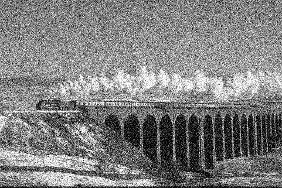

```python
from PIL import Image

img = Image.open('./my_data/Set68/BRUNSJRV@TCD.IE_033.png')

print('Corrupted Image')
display(img)
```

```
2019-11-21 16:57:56: load trained model
     Set68 : BRUNSJRV@TCD.IE_033.png : 0.0665 second
2019-11-21 16:57:56: Datset: Set68
  PSNR = 21.09dB, SSIM = 0.8972
Pre-trained image
```

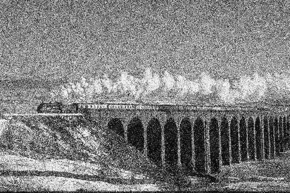

```python
pre_trained_out, _ = test(sigma=25, set_dir='./my_data', model_path='./DnCNN/models/model_000.pth',
                          result_dir='./pretrained_results')

img = Image.open('./pretrained_results/Set68/BRUNSJRV@TCD.IE_033_dncnn.png')

print('Pre-trained image')
display(img)

img.save('./submission/BRUNSJRV@TCD.IE_pretrained.png')
```

```
2019-11-21 16:57:59: load trained model
     Set68 : BRUNSJRV@TCD.IE_033.png : 0.0646 second
2019-11-21 16:57:59: Datset: Set68
  PSNR = 15.96dB, SSIM = 0.5866
Fine-tuned image
```

[figure not shown]

```python
import pandas as pd

fine_tuned_out, _ = test(sigma=52, set_dir='./my_data', model_path='./models/model_001.pth',
                         result_dir='./finetuned_results')

img = Image.open('./finetuned_results/Set68/BRUNSJRV@TCD.IE_033_dncnn.png')

print('Fine-tuned image')
display(img)

img.save('./submission/BRUNSJRV@TCD.IE_clean.png')

pd.DataFrame([pre_trained_out, fine_tuned_out]).to_csv('./submission/BRUNSJRV@TCD.IE_psnr.csv',
                                                       header=False, index=False)
```

## e) Modify the network to output the estimated noise (Residual image in Fig.1) instead of the clean image. Generate noise from YourEmail_XXX.png by your finetuned network and save it as a grayscale image centered around intensity 127 named YourEmail_XXX_noise.png. Report the standard deviation of the noise in this image.

```
2019-11-21 16:58:02: load trained model
     Set68 : BRUNSJRV@TCD.IE_033.png : 0.0700 second
2019-11-21 16:58:03: Datset: Set68
  PSNR = 5.08dB, SSIM = -0.0005
```

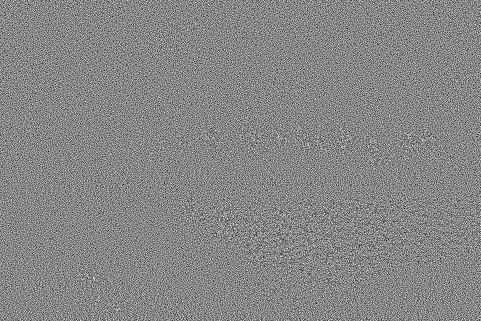

```
31.61191177368164 - Noise image standard deviation
```

```python
class DnCNN(nn.Module):

    def __init__(self, depth=17, n_channels=64, image_channels=1, use_bnorm=True, kernel_size=3):
        super(DnCNN, self).__init__()
        kernel_size = 3
        padding = 1
        layers = []
        layers.append(nn.Conv2d(in_channels=image_channels, out_channels=n_channels, kernel_size=kernel_size,
                                padding=padding, bias=True))
        layers.append(nn.ReLU(inplace=True))
        for _ in range(depth-2):
            layers.append(nn.Conv2d(in_channels=n_channels, out_channels=n_channels, kernel_size=kernel_size,
                                    padding=padding, bias=False))
            layers.append(nn.BatchNorm2d(n_channels))
            layers.append(nn.ReLU(inplace=True))
        layers.append(nn.Conv2d(in_channels=n_channels, out_channels=image_channels, kernel_size=kernel_size,
                                padding=padding, bias=False))
        self.dncnn = nn.Sequential(*layers)
        self._initialize_weights()

    def forward(self, x):
        y = x
        out = self.dncnn(x)
        return out

    def _initialize_weights(self):
        for m in self.modules():
            if isinstance(m, nn.Conv2d):
                init.orthogonal_(m.weight)
                print('init weight')
                if m.bias is not None:
                    init.constant_(m.bias, 0)
            elif isinstance(m, nn.BatchNorm2d):
                init.constant_(m.weight, 1)
                init.constant_(m.bias, 0)

_, imgs = test(sigma=52, set_dir='./my_data', model_path='./models/model_001.pth', result_dir='./noise_results')

img_arr = imgs[0]
img_arr = img_arr - img_arr.min()
img_arr = img_arr / img_arr.max()
img_arr = img_arr * 255.0

img = Image.fromarray(np.uint8(np.clip(img_arr, 0, 255)))

display(img)

img.save('./submission/BRUNSJRV@TCD.IE_noise.png')

print('{} - Noise image standard deviation'.format(np.std(img_arr)))
```